# PRÁCTICA 3: LEY DE HOOKE, OSCILADOR ARMÓNICO

**Autor responsable:** Pablo Corbalán de Concepción.

**Autores**: Pablo Corbalán de Concepción y Víctor Mula Navarro.

**Grupo:** G4 - DTIE.

**Fecha del informe:** 26/02/2026.

## INFORMACIÓN GENERAL DEL LABORATORIO

**Fecha de realización de la práctica:** 18/02/2026.

**Temperatura:** 21.6ºC

**Humedad relativa:** 36%

**Presión:** 1031.6 hPa

## 1. INTRODUCCIÓN Y OBJETIVOS

Un muelle es un objeto que presenta propiedades especiales a la hora del estudio de su movimiento. Cuando es perturbado de su equilibrio, en casos ideales, presenta un movimiento armónico simple en torno a un punto de equilibrio. Cada muelle tiene asociada una constante $k$ de elasticidad, que representa la fuerza que se le tiene que aplicar a un muelle para que se elongue una unidad de longitud.

Además, si suspendemos el muelle en un soporte vertical, su movimiento se verá también sujeto a la ley de la gravedad. Obteniendo una relación entre varias magnitudes como lo pueden ser la constante $k$, la aceleración de la gravedad $g$, entre otras. Por tanto, los objetivos de esta práctica son:

- Comprobar la ley de Hooke experimentalmente con un muelle.
- Obtener la constante elástica $k$ de un muelle.
- Obtener experimentalmente el valor de la aceleración de la gravedad $g$.
- Comprobar la ecuación del periodo para un oscilador armónico simple.
- Determinar la influencia de la masa del muelle en el experimento.

## 2. Marco Teórico General

### 2.1. Experiencia estática: Ley de Hooke

De acuerdo con la ley de Hooke, un muelle al que se le aplica una fuerza $F$ experimenta un estiramiento o elongación de forma proporcional a dicha fuerza. Esta relación se expresa matemáticamente mediante la ecuación:

$$\Delta l=\frac{1}{k}F$$

Donde $\Delta l=l-l_{0}$ representa la elongación del muelle, siendo $l_{0}$ su longitud de equilibrio (que corresponde a la longitud del muelle con el portapesas colgado) y $l$ la longitud final tras aplicar la fuerza de las pesas adicionales. La constante elástica $k$ es una característica intrínseca del muelle que depende del material y de su geometría. En esta experiencia, la fuerza aplicada corresponde al peso de una masa $M$, cumpliéndose en el equilibrio que $Mg=k\Delta l$.

### 2.2. Experiencia dinámica: Oscilador armónico

Si el muelle, cargado con una masa $M$ en su estado de equilibrio, se estira ligeramente y se suelta, la masa oscila en torno a su posición de equilibrio realizando un movimiento armónico simple. La ecuación diferencial que rige este movimiento es:

$$\frac{d^{2}(\Delta l)}{dt^{2}}+\omega^{2}\Delta l=0$$

Donde $\omega^{2}=k/M$. A partir de la relación con el periodo de oscilación $T=2\pi/\omega$, se obtiene que el periodo de un oscilador ideal viene dado por:

$$T=2\pi\sqrt{\frac{M}{k}}$$

### 2.3. Influencia de la masa del muelle y determinación de variables

Si planteamos un segundo análisis más preciso, no debemos despreciar la masa del muelle $m^*$, ya que esta contribuye a la masa efectiva que oscila. Para corregir este efecto, se utiliza la relación $M=Nm+\alpha m^*$, donde $N$ es el número de pesas y $\alpha \simeq 1/3$ es un parámetro que ajusta la influencia de la masa del muelle. La ecuación final para el análisis de datos se convierte en:

$$T^{2}=\frac{4\pi^{2}m}{k}N+\frac{4\pi^{2}\alpha m^{*}}{k}$$

A través de ajustes lineales por mínimos cuadrados de $\Delta l$ frente a $N$ y de $T^2$ frente a $N$, es posible determinar experimentalmente la constante elástica $k$, la aceleración de la gravedad $g$ y el factor de influencia $\alpha$, comparándolos posteriormente con sus valores nominales.

## 3. Montaje experimental y procedimiento seguido

El componente central del experimento es un muelle suspendido verticalmente de un soporte robusto mediante una varilla metálica. En el extremo inferior del muelle se colocó un portapesas, que sirve como base para añadir masas de forma estable. Para la medición de las elongaciones en la fase estática, se dispuso una regla graduada en posición vertical paralela al muelle, permitiendo registrar la posición del extremo inferior respecto a un punto de referencia fijo. En la fase dinámica, se utilizó un cronómetro digital para medir los periodos de oscilación.

El procedimiento se dividió en dos etapas diferenciadas. En la primera, de carácter estático, se añadieron sucesivamente pesas al portapesas, registrando la longitud final del muelle tras cada adición una vez alcanzado el equilibrio. Esto permitió determinar la elongación respecto a la longitud inicial. En la segunda etapa, de carácter dinámico, se desplazó el sistema masa-muelle de su posición de equilibrio y se liberó para iniciar un movimiento armónico simple. Se cronometró el tiempo necesario para completar 20 oscilaciones completas para diferentes masas, repitiendo cada medición tres veces para minimizar el error de precisión y obtener un valor medio del periodo fiable. De esta segunda experiencia (dinámica) podemos obtener la constante de elasticidad del muelle para así calcular el valor de la aceleración gravitaroria.

Para la realización de estas medidas, se emplearon los siguientes instrumentos de medida, especificando su resolución:

- Regla graduada: Utilizada para medir la longitud y elongación del muelle, con una resolución de 1 mm (0,001 m).
- Balanza digital: Empleada para verificar la masa de las pesas y el portapesas, con una resolución de 0,01 g (0,0001 kg).
- Cronómetro digital: Utilizado para la medición del tiempo de las oscilaciones en la experiencia dinámica, con una resolución de 0,01 s.

## 4. Resultados

#### 4.2.1 Medidas de masa

Las medidas de las masas realizadas con la balanza han sido las siguientes:

| Elemento | Masa (g) |
| --- | --- |
| Pesa 1 | 20.38 |
| Pesa 2 | 20.32 |
| Pesa 3 | 20.15 |
| Pesa 4 | 19.91 |
| Pesa 5 | 20.12 |
| Portapesas | 19.93 |
| Muelle ($m^*$) | 16.47 |

En adelante, trabajaremos con el valor medio de ellas:

$$ \bar m = \frac{\sum_{i= 1}^5 m_i}{5}$$

La incertidumbre asociada a esta magnitud tiene componente tipo a y tipo b. La tipo a está asociada a la varianza y sigue la expresión:

$$ u_a = \frac{s}{\sqrt{5}}$$

siendo:

$$ s^2 = \frac{1}{4} \sum_{i=1}^5 (m_i - \bar m)^2$$

Con respecto a la incertidumbre tipo b, al hacerse las mediciones con un aparato digital, se sigue una distribución rectangular. Sea $\Delta$ la resolución de la balanza, entonces:

$$ u_b = \frac{\Delta}{\sqrt{12}}$$

Por tanto, la incertidumbre total:

$$ u_m^2 = u_a^2 + u_b^2$$

Expresaremos pues la masa:

$$m = 20.176 \pm 0.083 \text{ g }$$

Los cálculos realizados para determinar este valor de la masa se han efectuado en el anexo 7.1.

### 4.2 Tablas con los datos de las medidas realizadas

#### 4.2.2 Experiencia Estática

| $N$ (pesas) | $l_N$ (cm) | $\Delta l$ (cm) | $\Delta l$ (m) |
| --- | --- | --- | --- |
| 0 (portapesas) | 8.6 ($l_0$) | 0.0 | 0.000 |
| 1 | 12.3 | 3.7 | 0.037 |
| 2 | 16.1 | 7.5 | 0.075 |
| 3 | 19.4 | 10.8 | 0.108 |
| 4 | 23.0 | 14.4 | 0.144 |
| 5 | 26.5 | 17.9 | 0.179 |

#### 4.2.3 Experiencia Dinámica

| $N$ | $t_{20}^{(1)}$ (s) | $t_{20}^{(2)}$ (s) | $t_{20}^{(3)}$ (s) | $t_{20}$ medio (s) | $T^2$ ($s^2$) |
| --- | --- | --- | --- | --- | --- |
| 1 | 8.76 | 8.60 | 8.44 | 8.60 | 0.1849 |
| 2 | 11.53 | 11.74 | 11.72 | 11.66 | 0.3401 |
| 3 | 13.54 | 13.61 | 13.93 | 13.69 | 0.4688 |
| 4 | 15.67 | 15.75 | 15.53 | 15.65 | 0.6123 |
| 5 | 17.98 | 17.30 | 17.40 | 17.56 | 0.7709 |
| 6 | 18.88 | 18.77 | 18.92 | 18.86 | 0.8889 |

### 4.3 Cálculo de las constantes elásticas y del parámetro $\alpha$

En esta sección se presentan los valores obtenidos para la constante elástica del muelle ($k$) y el parámetro de masa efectiva ($\alpha$), calculados a partir de los resultados de la regresión lineal de ambas experiencias. En ambas experiencias se ha utilizado el valor de las masas obtenido en el apartado 4.2.1.

#### 4.3.1 Constante elástica (experiencia dinámica)

Según la Ecuación (7) del guion, la relación entre el periodo y el número de pesas es $T^2 = \frac{4\pi^2 m}{k}N$. Por tanto, la pendiente $a$ de la recta de regresión permite obtener $k$. Asimismo, la Ecuación (8) permite obtener $\alpha$ a partir de la ordenada en el origen $b$.

Donde la incertidumbre se ha calculado con la fórmula de propagación de incertidumbres para producto de magnitudes. En particular:

$$u_k = \overline{k}\cdot\sqrt{\epsilon_m^2 + \epsilon_a^2} = \overline{k}\cdot\sqrt{\left(\frac{u_m}{\overline{m}}\right)^2 + \left(\frac{u_a}{\overline{a}}\right)^2}$$

#### 4.3.3 Aceleración debida a la gravedad $g$

Una vez calculada la constante elástica del muelle podemos calcular la aceleración debida a la fuerza de la gravedad despejando de la ecuación:

$$\Delta l = \left( \frac{g \cdot m}{k} \right) N$$

Esta expresión representa una relación lineal de $\Delta l$ frente a $N$, donde la pendiente experimental $a$ está definida por:

$$a = \frac{g \cdot m}{k}$$

Concluimos entonces:

$$g= 9.95 ± 0.20 m/s^2$$

Donde el valor de la incertidumbre asociada ha sido calculado como:

$$u_{g} = \overline{g}\cdot\sqrt{\left(\frac{u_k}{\overline{k}}\right)^2 + \left(\frac{u_a}{\overline{a}}\right)^2 + \left(\frac{u_{m}}{\overline{m}}\right)^2}$$

Los valores de las incertidumbres han sido detallados en las dos secciones inmediatamente anteriores.

### 4.4 Gráficas de regresión lineal

Se ha efectuado la regresión lineal para visualizar la relación entre la carga aplicada y la deformación del muelle, se presenta la gráfica de la elongación ($\Delta l$) en función del número de pesas ($N$):

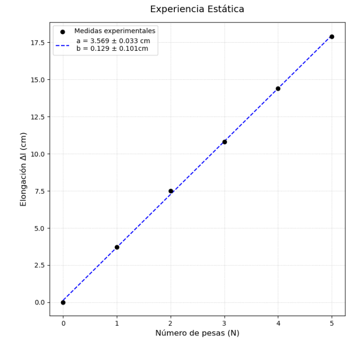

Para la experiencia dinámica hemos expresado $T^2$ frente al número de pesas, de donde podemos nuevamente despejar la constante elástica:

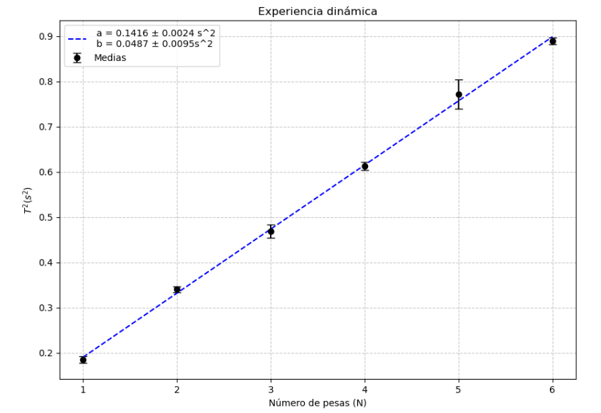

## 5. Discusión y conclusiones

El objetivo principal de la práctica consistía en determinar la constante elástica de un muelle mediante duna aproximación dinámica, fundamentada en el periodo de oscilación de un sistema masa-muelle.

La experiencia dinámica arrojó un valor de

$$k_{dinámica} = 5.625 ± 0.099 N/m$$

Tomando como referencia el valor nominal: $$k_{nominal} = 5 N/m $$Indicado en la bibliografía podemos analizar el error relativo de esta experiencia, cuyo error relativo resulta ser:

$$\epsilon_{dinámica}=0.1250$$

Expresados en tanto por uno. Este desfase, aunque no despreciable, es razonable en un entorno de laboratorio experimental y puede atribuirse a errores humanos a la hora de efectuar las medidas correspondientes. Además, el procedimiento dinámico es especialmente sensible a errores sistemáticos. En cuanto a las posibles fuentes de error, debemos incluir el error sistemático inducido por el cronometraje manual de las oscilaciones debido al tiempo de reacción humano. Además, oscilaciones laterales pueden haber alterando el periodo medido: al no tratarse de un oscilador armónico unidimensional, las ecuaciones no son fieles a la realidad.

### Estudio de la contribución de la masa del muelle

Un aspecto crítico de la discusión es la determinación de la masa efectiva del muelle a través del parámetro alfa. El modelo teórico para un muelle ideal sugiere que este valor debería ser: $$\alpha_{teórico} = \frac{1}{3}$$ En nuestro análisis dinámico, el valor obtenido experimentalmente fue de

El error relativo es:

$$\epsilon_{\alpha} = 0.033$$

Respecto al valor teórico. Este resultado confirma que la ecuación: $$T^{2}=\frac{4\pi^{2}m}{k}N+\frac{4\pi^{2}\alpha m^{*}}{k}$$ Es una buena correción de la Ecuación que describe el periodo del oscilador armónico sin tener en cuenta la masa del muelle.

### Estudio de la aceleración gravitatoria.

Tras realizar el ajuste lineal de la elongación frente al número de pesas ($\Delta l$ frente a $N$), se ha obtenido un valor experimental para la aceleración de la gravedad de $$g_{exp} \pm u_{g} = 9.95 ± 0.20m/s^2$$.

Para cuantificar la exactitud del experimento, comparamos nuestro resultado con el valor nominal de la gravedad estándar ($g_{teórico} = 9.807 \, m/s^2$). Nuestras medidas presentan un error relativo de:

$$\epsilon_g = \frac{9.807 - 9.95}{9.807} \times 100 = -1.46\%$$

Expresado en tanto por ciento. Este resultado muestra que la ecuación (4) de la experiencia estática describe con gran precisión el comportamiento del sistema, validando la Ley de Hooke y la consistencia de los parámetros calculados en la fase dinámica.

## 6. Bibliografía

Departamento de Física. (2026). *Práctica 3: Ley de Hooke - Oscilador armónico* [Guion de prácticas]. Universidad de Murcia.

Tiesinga, E., Mohr, P. J., Newell, D. B., & Taylor, B. N. (2021). The 2018 CODATA recommended values of the fundamental physical constants. National Institute of Standards and Technology. https://physics.nist.gov/cuu/Constants/

## 7. Anexos: Cálculos de Python

Para realizar los cálculos cargamos las siguientes librerías

```python
import numpy as np
import math
import matplotlib.pyplot as plt
from __future__ import print_function
from scipy import stats
from scipy.optimize import curve_fit
from scipy.stats import t
from scipy.odr import *
```

### 7.1. Cálculo de la masa y su incertidumbre

En ambas experiencias se han utilizado las mismas medidas para la masa:

```python
masas_g = [20.38, 20.32, 20.15, 19.91, 20.12]
m = (sum(masas_g) / len(masas_g))
print(f"Masa promedio de las pesas: {m} g")
```

```
Masa promedio de las pesas: 20.176 g
```

```python
error_balanza = 0.01
u_a = np.std(masas_g, ddof=1) / np.sqrt(len(masas_g))
u_b = error_balanza / np.sqrt(12)

u_m = np.sqrt(u_a**2 + u_b**2)

print(f"Masa promedio m = ({m:.3f} ± {u_m:.3f}) g")
```

```
Masa promedio m = (20.176 ± 0.083) g
```

### 7.2. Cálculo de la constante elástica: experiencia dinámica

```python
# DATOS DE LA EXPERIENCIA DINÁMICA
N_dinamica = np.array([1, 2, 3, 4, 5, 6])
t20_1 = [8.76, 11.53, 13.54, 15.67, 17.98, 18.88]
t20_2 = [8.60, 11.74, 13.61, 15.75, 17.30, 18.77]
t20_3 = [8.44, 11.72, 13.93, 15.53, 17.40, 18.92]
```

```python
t20_promedio = [(t1 + t2 + t3) / 3 for t1, t2, t3 in zip(t20_1, t20_2, t20_3)]
```

```python
periodo_T = [t / 20 for t in t20_promedio]
periodo_T2 = [t**2 for t in periodo_T]
```

Si hacemos la regresión lineal teniendo en cuenta las tres medidas que hemos tomado:

```python
def lineal_model(parameters, x):
    A, B = parameters
    return A * x + B

t20_varianza = np.var([t20_1, t20_2, t20_3], axis=0, ddof=1)
t20_std = np.sqrt(t20_varianza)
T2varianza = (np.array(t20_promedio) / 200)**2 * t20_varianza # Propagación de las varianzas muestrales
T2std = np.sqrt(T2varianza)

res_dinamica = stats.linregress(N_dinamica, periodo_T2)
beta_auto = [res_dinamica.slope, res_dinamica.intercept]

modelo = Model(lineal_model)
data = RealData(N_dinamica, periodo_T2, sy=T2std)
odr = ODR(data, modelo, beta0=beta_auto)
out = odr.run()
beta_final = out.beta
```

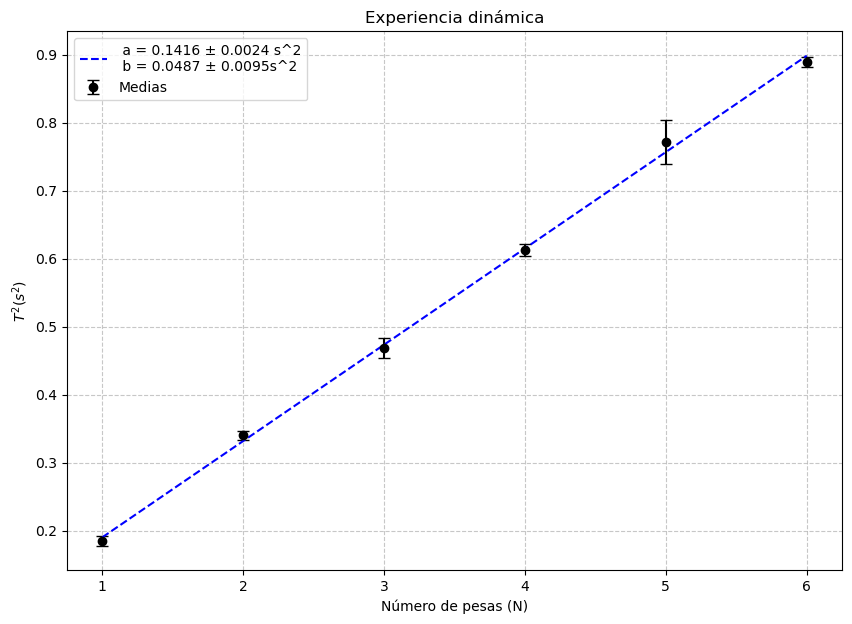

```python
plt.figure(figsize=(10, 7))
plt.errorbar(N_dinamica, periodo_T2, yerr=T2std, fmt='ko', capsize=4, label='Medias')
plt.plot(N_dinamica, lineal_model(beta_final, N_dinamica), 'b--', label=f' a = {beta_final[0]:.4f} ± {round(res_dinamica.stderr,4)} s^2\n b = {beta_final[1]:.4f} ± {round(res_dinamica.intercept_stderr, 4)}s^2')

plt.xlabel('Número de pesas (N)')
plt.ylabel('$T^2 (s^2)$')
plt.title('Experiencia dinámica')
plt.grid(True, linestyle='--', alpha=0.7)
plt.legend()
plt.show()
```

```python
k_experimental = (4 * (math.pi**2) * (m/1000)) / res_dinamica.slope

error_relativo_m = u_m / m
error_relativo_a = res_dinamica.stderr / res_dinamica.slope
u_k = k_experimental * np.sqrt(error_relativo_m**2 + error_relativo_a**2)

print(f"Constante del muelle, experiencia dinámica: {k_experimental:.3f} ± {u_k:.3f} N/m")
```

```
Constante del muelle, experiencia dinámica: 5.625 ± 0.099 N/m
```

### 7.3. Cálculo del parámetro $\alpha$

```python
# Cálculo de alfa
b = res_dinamica.intercept
u_b = res_dinamica.intercept_stderr
alpha = (b * k_experimental) / (4 * (np.pi**2) * (m/1000))
u_alpha = alpha * np.sqrt((u_b/b)**2 + (u_k/k_experimental)**2 + (u_k/k_experimental)**2)

print(f"Valor experimental de alpha: {round(alpha, 3)} ± {u_alpha:.3f}")
```

```
Valor experimental de alpha: 0.344 ± 0.068
```

### 7.4. Calculo de la aceleración gravitatoria: experiencia estática

```python
# DATOS DE LA EXPERIENCIA ESTÁTICA
N = np.array([0, 1, 2, 3, 4, 5])
l_n = [8.6, 12.3, 16.1, 19.4, 23.0, 26.5]
delta_l = [0.0, 3.7, 7.5, 10.8, 14.4, 17.9]
```

```python
res = stats.linregress(N, delta_l)
print(f"R cuadrado: {res.rvalue**2:.6f}")
print(f"Ordenada en el origen: {res.intercept:.6f} cm")
print(f"Error de la ordenada en el origen: {res.intercept_stderr:.6f} cm")
print(f"Pendiente: {res.slope:.6f} cm")
print(f"Error de la pendiente: {res.stderr:.6f} cm")
```

```
R cuadrado: 0.999651
Ordenada en el origen: 0.128571 cm
Error de la ordenada en el origen: 0.100880 cm
Pendiente: 3.568571 cm
Error de la pendiente: 0.033320 cm
```

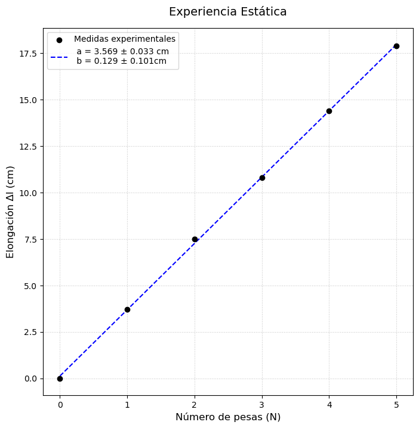

```python
plt.figure(figsize=(8, 8))
plt.scatter(N, delta_l, color='black', zorder=5, label="Medidas experimentales")
plt.plot(N, res.slope*N + res.intercept, color='blue', linestyle='--', label=f' a = {res.slope:.3f} ± {round(res.stderr,3)} cm\n b = {res.intercept:.3f} ± {round(res.intercept_stderr, 3)}cm')

plt.title('Experiencia Estática', fontsize=14, pad=15)
plt.xlabel('Número de pesas (N)', fontsize=12)
plt.ylabel('Elongación Δl (cm)', fontsize=12)
plt.grid(True, linestyle=':', alpha=0.7)
plt.legend()
plt.show()
```

```python
g_promedio = ((res.slope / 100) * k_experimental) / (m / 1000)

rel_error_a = res.stderr / res.slope
rel_error_k = u_k / k_experimental
rel_error_m = u_m / m

error_g = g_promedio * np.sqrt(rel_error_a**2 + rel_error_k**2 + rel_error_m**2)

print(f"Aceleración de la gravedad (Estática): {round(g_promedio, 2)} ± {error_g:.2f} m/s^2")
```

```
Aceleración de la gravedad (Estática): 9.95 ± 0.20 m/s^2
```